# 7-Confirmatory-Factor-Analysis-Assignment

## Setup and Data Prep

This assignment uses a daily stock return dataset. The fields are companies, with MAN being manufacturing and Serv being service.

|  | Man1 | Man2 | Man3 | Serv1 | Serv2 | Serv3 | Serv4 |
| --- | --- | --- | --- | --- | --- | --- | --- |
| 1 | -1.0376336 | -0.2811634 | 0.1044327 | 0.4206954 | -0.4319530 | -1.1520534 | -0.0218869 |
| 2 | -1.5294139 | -1.7052611 | -0.2008442 | 1.3144198 | 0.3391672 | -0.5959107 | 0.5752426 |
| 3 | -0.5597689 | -0.0867514 | 0.7647221 | 0.2495059 | -0.4570792 | -1.1096758 | 1.0483611 |
| 4 | -0.6594511 | 0.8015072 | 0.2140318 | -0.6727501 | -0.3915131 | 0.4250358 | 0.5515717 |
| 5 | 0.8006007 | -0.4137202 | -0.2886513 | 1.1790268 | 1.1174818 | 1.3899308 | -0.6460089 |
| 6 | 0.9088881 | -0.2099296 | 0.6839741 | 0.8345575 | -0.4702975 | -0.1639780 | -0.3244047 |

Load the Sem packages:

```r
install.packages("sem", repos = "http://cran.us.r-project.org")
```

```r
install.packages("semPlot", repos = "http://cran.us.r-project.org")
```

```r
library(sem)
```

## a) Perform confirmatory factor analysis base on two factors: manufacturing and service.

To create this model, we specify the factors we are testing for each manifest variable. We also pass in the correlation between the factors to be read out as rho, and the individual variances of each column.

```r
stock_model <- specifyModel(text = "
                 Manu -> Man1, lambda1, NA
                 Manu -> Man2, lambda2, NA
                 Manu -> Man3, lambda3, NA
                 Serv -> Serv1, lambda4, NA
                 Serv -> Serv2, lambda5, NA
                 Serv -> Serv3, lambda6, NA
                 Serv -> Serv4, lambda7, NA
                 Manu <-> Serv, rho, NA
                 Man1 <-> Man1, theta1, NA
                 Man2 <-> Man2, theta2, NA
                 Man3 <-> Man3, theta3, NA
                 Serv1 <-> Serv1, theta4, NA
                 Serv2 <-> Serv2, theta5, NA
                 Serv3 <-> Serv3, theta6, NA
                 Serv4 <-> Serv4, theta7, NA
                 Manu <-> Manu, NA, 1
                 Serv <-> Serv, NA, 1
                ")
```

```
Read 17 records
NOTE: it is generally simpler to use specifyEquations() or cfa()
      see ?specifyEquations
```

```r
stock_sem <- sem(stock_model, cor(mydata), nrow(mydata))
summary(stock_sem)
```

```
 Model Chisquare =  8.696696   Df =  13 Pr(>Chisq) = 0.7954455
 AIC =  38.6967
 BIC =  -81.3743

 Normalized Residuals
      Min.    1st Qu.     Median       Mean    3rd Qu.       Max.
-0.5848593 -0.3589473 -0.0000011  0.0737239  0.2515302  1.1401712

 R-square for Endogenous Variables
  Man1   Man2   Man3  Serv1  Serv2  Serv3  Serv4
0.2400 0.4940 0.4667 0.1061 0.2889 0.2188 0.4018

 Parameter Estimates
```

|  | Estimate | Std Error | z value | Pr(>\|z\|) |  |
| --- | --- | --- | --- | --- | --- |
| lambda1 | 0.4898527 | 0.03587045 | 13.656164 | 1.855024e-42 | Man1 <--- Manu |
| lambda2 | 0.7028188 | 0.03768934 | 18.647681 | 1.318745e-77 | Man2 <--- Manu |
| lambda3 | 0.6831474 | 0.03743433 | 18.249223 | 2.098718e-74 | Man3 <--- Manu |
| lambda4 | 0.3257044 | 0.03910335 | 8.329323 | 8.130615e-17 | Serv1 <--- Serv |
| lambda5 | 0.5374555 | 0.03948475 | 13.611725 | 3.410985e-42 | Serv2 <--- Serv |
| lambda6 | 0.4677928 | 0.03901408 | 11.990357 | 3.991827e-33 | Serv3 <--- Serv |
| lambda7 | 0.6338432 | 0.04079451 | 15.537464 | 1.934900e-54 | Serv4 <--- Serv |
| rho | 0.4828152 | 0.04321207 | 11.173155 | 5.518540e-29 | Serv Manu |
| theta1 | 0.7600445 | 0.03923737 | 19.370423 | 1.371273e-83 | Man1 Man1 |
| theta2 | 0.5060457 | 0.04301257 | 11.765065 | 5.908071e-32 | Man2 Man2 |

[output cut: 5 more lines]

```
 Iterations =  17
```

## b) Report the path diagram that shows coefficient estimates. Code: library(semPlot); semPaths(fitted.sem.object, “est”)

The path diagram helps us visualize the model we just created. To build it, we use the semPlot package and call the `semPaths()` function:

```r
library(semPlot)
```

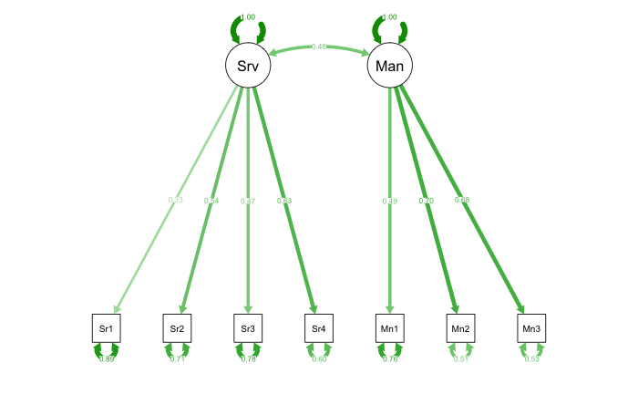

## c) Report SRMR, GFI, and AGFI. What do you conclude? Is the model you made in part (a) approved.

The root-mean-square, goodness-of-fit, and adjusted goodness-of-fit can be pulled from the summary of our CFA analysis. The SRMR (RMSE) is < 0.05 and the goodness-of-fit tests are both > 0.95 which all imply that the data supports the CFA model.

```r
options(fit.indices = c("GFI", "AGFI", "SRMR")) # Some fit indices
criteria = summary(stock_sem)
criteria$SRMR
```

```
[1] 0.01468043
```

```r
criteria$GFI
```

```
[1] 0.9975558
```

```r
criteria$AGFI
```

```
[1] 0.9947356
```

## d) Find the 95% confidence interval for the correlation between the two factors: manufacturing and service returns.

The Confidence Interval is found by adding or subtracting the product of 1.96 and the standard error from the correlation estimate to get the upper and lower bounds.

```r
parameters = summary(stock_sem)

# Calculate the lower bound
conf.L = parameters$coeff[8,]$Estimate - 1.96 * parameters$coeff[8,]$'Std Error'
conf.L
```

```
[1] 0.3981195
```

```r
# Calculate the upper bound
conf.U = parameters$coeff[8,]$Estimate + 1.96 * parameters$coeff[8,]$'Std Error'
conf.U
```

```
[1] 0.5675109
```